# Plant Seedling Image Classification Using CNN

You are provided with a trainingset and a test set of images of plant seedlings at various stages of grown. Each image has a filename that is its unique id. The dataset comprises 12 plant species. The goal of the competition is to create a classifiercapable of determining a plant's species from a photo.

## Context

Can you differentiate a weed from a crop seedling?The ability to do so effectively can mean better crop yields and better stewardship of the environment.The Aarhus University Signal Processing group, in collaboration with University of Southern Denmark, has recently released a dataset containing images of unique plants belonging to 12 species at several growth stages

```python
# Import necessary libraries.
import cv2
import math
import numpy as np
import pandas as pd
from glob import glob
from matplotlib import pyplot as plt

from tensorflow.keras import models, layers, optimizers
from tensorflow.keras.models import Sequential
from sklearn.preprocessing import OneHotEncoder
from sklearn.model_selection import train_test_split
from tensorflow.keras.layers import Dense, Dropout, Flatten, Conv2D, MaxPool2D, GlobalMaxPooling2D
from tensorflow.keras.layers import BatchNormalization
from tensorflow.keras.optimizers import RMSprop, Adam
from keras.utils.np_utils import to_categorical # convert to one-hot-encoding
from tensorflow.keras.preprocessing.image import ImageDataGenerator
```

```python
train_path = "/Users/vishnunair/Downloads/train.zip"
!mkdir temp_train
```

```
mkdir: temp_train: File exists
```

```python
from zipfile import ZipFile
with ZipFile(train_path, 'r') as zip:
  zip.extractall('./temp_train')
```

```python
path = "./temp_train/*/*.png"                              # The path to all images in training set. (* means include all folders and files.)
files = glob(path)

trainImg = []                                              # Initialize empty list to store the image data as numbers.
trainLabel = []                                            # Initialize empty list to store the labels of images
j = 1
num = len(files)

# Obtain images and resizing, obtain labels
for img in files:
    '''
    Append the image data to trainImg list.
    Append the labels to trainLabel list.
    '''
    print(str(j) + "/" + str(num), end="\r")
    trainImg.append(cv2.resize(cv2.imread(img), (128, 128)))  # Get image (with resizing to 128x128)
    trainLabel.append(img.split('/')[-2])  # Get image label (folder name contains the class to which the image belong)
    j += 1

trainImg = np.asarray(trainImg)  # Train images set
trainLabel = pd.DataFrame(trainLabel)  # Train labels set
```

```
4750/4750
```

```python
#We have 4750 colored images that are 128 x 128 pixels
print(trainImg.shape)
print(trainLabel.shape)
```

```
(4750, 128, 128, 3)
(4750, 1)
```

```python
#It seems that there are unequal amounts of each class
#This may negatively affect our model
#Namely, it will likely classify loose silky-bent and common chickweed better than all other classes
trainLabel[0].value_counts()
```

```
Loose Silky-bent             654
Common Chickweed             611
Scentless Mayweed            516
Small-flowered Cranesbill    496
Fat Hen                      475
Charlock                     390
Sugar beet                   385
Cleavers                     287
Black-grass                  263
Shepherds Purse              231
Common wheat                 221
Maize                        221
Name: 0, dtype: int64
```

## Data Preprocessing

```
Cleavers
```

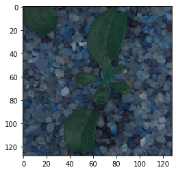

```
Sugar beet
```

[figure not shown]

```
Common Chickweed
```

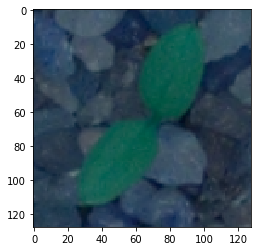

```
Loose Silky-bent
```

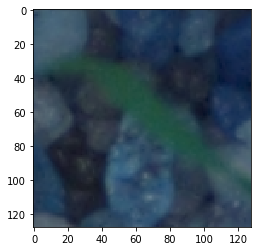

```
Loose Silky-bent
```

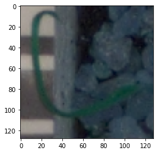

```
Scentless Mayweed
```

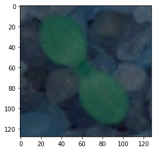

```
Fat Hen
```

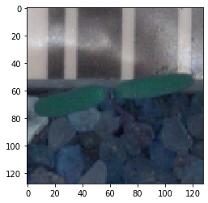

```
Common wheat
```

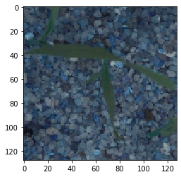

```
Small-flowered Cranesbill
```

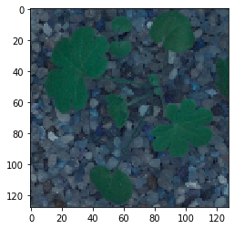

```
Charlock
```

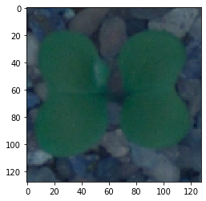

```python
#Here is a very small sample of the different types of plant images I am working with
i = 0
for i in np.arange(4750, step =475):
    print(trainLabel[0][i])
    plt.imshow(trainImg[i])
    plt.show()
```

```python
#Since the pixel values range from 0 to 255 for the RGB channels, I divide the x_train data by 255
trainImg = trainImg.astype('float32')
trainImg /= 255.0
#Making a copy of X_test for visualization at the very end
X = trainImg
y = trainLabel
X_train9, X_test9, y_train9, y_test9 = train_test_split(X, y, test_size=0.3, random_state=1)
```

```
Cleavers
```

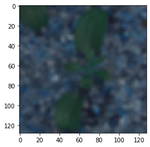

```
Sugar beet
```

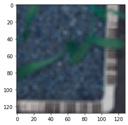

```
Common Chickweed
```

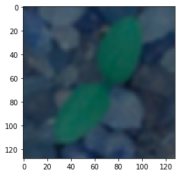

```
Loose Silky-bent
```

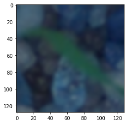

```
Loose Silky-bent
```

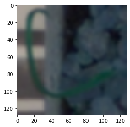

```
Scentless Mayweed
```

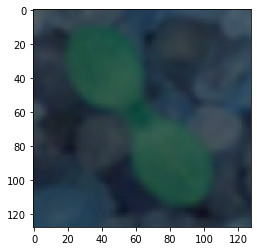

```
Fat Hen
```

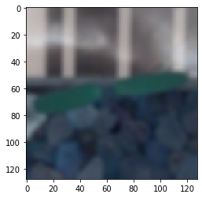

```
Common wheat
```

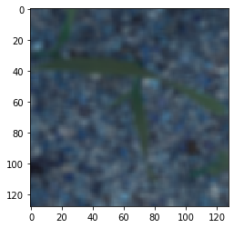

```
Small-flowered Cranesbill
```

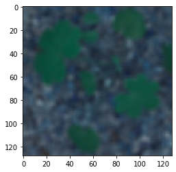

```
Charlock
```

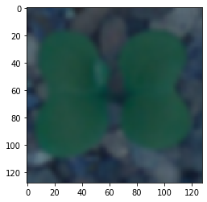

```python
#I convolve the Gaussian kernel with the images
#I am using a 5x5 kernel
#Here is an example of the first observation of the image data being blurred
for i in range(len(trainImg)):
    trainImg[i] = cv2.GaussianBlur(trainImg[i],(5,5),cv2.BORDER_DEFAULT)
for i in np.arange(4750, step =475):
    print(trainLabel[0][i])
    plt.imshow(trainImg[i])
    plt.show()
```

# Making the Data Compatible

```python
trainImg
```

[output not shown]

[output cut: 252 more lines]

[output not shown]

```python
X_train, X_test, y_train, y_test = train_test_split(X, y, test_size=0.3, random_state=1)
X_test, X_val, y_test, y_val = train_test_split(X_test, y_test, test_size=0.5, random_state=1)
y_test1 = y_test
```

```python
X_train.shape
```

```
(3325, 128, 128, 3)
```

```python
#Reshape data into shapes compatible with Keras models (will do if needed)
X_train = X_train.reshape(X_train.shape[0], 128, 128, 3)
X_val = X_val.reshape(X_val.shape[0], 128, 128, 3)
X_test = X_test.reshape(X_test.shape[0], 128, 128, 3)
```

```python
y_train = pd.get_dummies(y_train)
y_test = pd.get_dummies(y_test)
y_test2 = y_test
y_val = pd.get_dummies(y_val)
```

```python
#The label for the first y_train observation is 'Small-flowered Cranesbill'
y_train.iloc[0]
```

```
0_Black-grass                  0
0_Charlock                     0
0_Cleavers                     0
0_Common Chickweed             0
0_Common wheat                 0
0_Fat Hen                      0
0_Loose Silky-bent             0
0_Maize                        0
0_Scentless Mayweed            0
0_Shepherds Purse              0
0_Small-flowered Cranesbill    1
0_Sugar beet                   0
Name: 3702, dtype: uint8
```

```python
y_train
```

|  | 0_Black-grass | 0_Charlock | 0_Cleavers | 0_Common Chickweed | 0_Common wheat | 0_Fat Hen | 0_Loose Silky-bent | 0_Maize | 0_Scentless Mayweed | 0_Shepherds Purse | 0_Small-flowered Cranesbill | 0_Sugar beet |
| --- | --- | --- | --- | --- | --- | --- | --- | --- | --- | --- | --- | --- |
| 3702 | 0 | 0 | 0 | 0 | 0 | 0 | 0 | 0 | 0 | 0 | 1 | 0 |
| 4252 | 0 | 1 | 0 | 0 | 0 | 0 | 0 | 0 | 0 | 0 | 0 | 0 |
| 945 | 0 | 0 | 0 | 1 | 0 | 0 | 0 | 0 | 0 | 0 | 0 | 0 |
| 3610 | 1 | 0 | 0 | 0 | 0 | 0 | 0 | 0 | 0 | 0 | 0 | 0 |
| 4046 | 0 | 0 | 0 | 0 | 0 | 0 | 0 | 0 | 0 | 0 | 1 | 0 |
| ... | ... | ... | ... | ... | ... | ... | ... | ... | ... | ... | ... | ... |
| 2895 | 0 | 0 | 0 | 0 | 0 | 1 | 0 | 0 | 0 | 0 | 0 | 0 |
| 2763 | 0 | 0 | 0 | 0 | 0 | 1 | 0 | 0 | 0 | 0 | 0 | 0 |
| 905 | 0 | 0 | 0 | 1 | 0 | 0 | 0 | 0 | 0 | 0 | 0 | 0 |
| 3980 | 0 | 0 | 0 | 0 | 0 | 0 | 0 | 0 | 0 | 0 | 1 | 0 |
| 235 | 0 | 0 | 1 | 0 | 0 | 0 | 0 | 0 | 0 | 0 | 0 | 0 |

3325 rows × 12 columns

```python
X_train.shape
```

```
(3325, 128, 128, 3)
```

# Building the CNN Model

```python
batch_size = None

model = models.Sequential()
model.add(layers.Conv2D(128, (5, 5), padding='same', activation="relu", input_shape=X_train.shape[1:]))
model.add(layers.BatchNormalization())
model.add(layers.MaxPooling2D((2, 2)))
model.add(layers.Dropout(0.2))
model.add(layers.Conv2D(100, (5, 5), padding='same', activation="relu"))
model.add(layers.BatchNormalization())
model.add(layers.Dropout(0.2))
model.add(layers.Conv2D(75, (3, 3), padding='same', activation="relu"))
model.add(layers.BatchNormalization())
model.add(layers.MaxPooling2D((2, 2)))
model.add(layers.Dropout(0.2))
model.add(layers.Conv2D(50, (3, 3), padding='same', activation="relu"))
model.add(layers.BatchNormalization())
model.add(layers.MaxPooling2D((2, 2)))
model.add(layers.Dropout(0.5))

model.add(layers.GlobalMaxPooling2D())
model.add(layers.Dense(50, activation="relu"))
model.add(layers.Dropout(0.5))
model.add(layers.Dense(12, activation="softmax"))

model.summary()
```

```
Model: "sequential_5"
_________________________________________________________________
Layer (type)                 Output Shape              Param #
=================================================================
conv2d_18 (Conv2D)           (None, 128, 128, 128)     9728
_________________________________________________________________
batch_normalization_16 (Batc (None, 128, 128, 128)     512
_________________________________________________________________
max_pooling2d_15 (MaxPooling (None, 64, 64, 128)       0
_________________________________________________________________
dropout_21 (Dropout)         (None, 64, 64, 128)       0
_________________________________________________________________
conv2d_19 (Conv2D)           (None, 64, 64, 100)       320100
_________________________________________________________________
batch_normalization_17 (Batc (None, 64, 64, 100)       400
_________________________________________________________________
dropout_22 (Dropout)         (None, 64, 64, 100)       0
_________________________________________________________________
conv2d_20 (Conv2D)           (None, 64, 64, 75)        67575
_________________________________________________________________
batch_normalization_18 (Batc (None, 64, 64, 75)        300
_________________________________________________________________
max_pooling2d_16 (MaxPooling (None, 32, 32, 75)        0
_________________________________________________________________
dropout_23 (Dropout)         (None, 32, 32, 75)        0
_________________________________________________________________
conv2d_21 (Conv2D)           (None, 32, 32, 50)        33800
_________________________________________________________________
batch_normalization_19 (Batc (None, 32, 32, 50)        200
_________________________________________________________________
max_pooling2d_17 (MaxPooling (None, 16, 16, 50)        0
_________________________________________________________________
dropout_24 (Dropout)         (None, 16, 16, 50)        0
_________________________________________________________________
global_max_pooling2d_5 (Glob (None, 50)                0
_________________________________________________________________
dense_10 (Dense)             (None, 50)                2550
_________________________________________________________________
dropout_25 (Dropout)         (None, 50)                0
_________________________________________________________________
dense_11 (Dense)             (None, 12)                612
=================================================================
Total params: 435,777
Trainable params: 435,071
Non-trainable params: 706
_________________________________________________________________
```

```python
#initiate Adam optimizer
adam = optimizers.Adam(learning_rate=0.01)
# Let's train the model using RMSprop
model.compile(loss='categorical_crossentropy', optimizer=adam, metrics=['accuracy'])
```

```python
#This is the first model that I tried running
#It took a tremendously long time and did not have a good accuracy, so I terminated it midway
history = model.fit(X_train,
                    y_train,
                    batch_size=50,
                    epochs=100,
                    validation_data=(X_val, y_val),
                    shuffle=True,
                    verbose=1)

# plot training history
plt.plot(history.history['loss'], label='train')
plt.plot(history.history['val_loss'], label='validation')
plt.legend()
plt.show()
```

[output not shown]

```python
#Now, I try modifying the previous model in hopes of attaining a better accuracy
```

```python
model = models.Sequential()
# I instantiate a sequential model that follows the pattern: Conv2D, MaxPooling, Batchnormalization, dropout several times
model.add(layers.Conv2D(128, (5, 5), padding='same', activation="relu", input_shape=X_train.shape[1:]))
model.add(layers.MaxPooling2D((2, 2)))
model.add(layers.BatchNormalization())
model.add(layers.Conv2D(80, (3, 3), padding='same', activation="relu"))
model.add(layers.MaxPooling2D((2, 2)))
model.add(layers.BatchNormalization())
model.add(layers.Conv2D(80, (3, 3), padding='same', activation="relu"))
model.add(layers.MaxPooling2D((2, 2)))
model.add(layers.BatchNormalization())
model.add(layers.Dropout(0.2))
model.add(layers.BatchNormalization())
model.add(layers.Conv2D(128, (3, 3), padding='same', activation="relu"))
model.add(layers.MaxPooling2D((2, 2)))
#Adding a GlobalMaxPooling and Flatten layer before adding dense layers
#I add dropout consistently to avoid overfitting
model.add(layers.GlobalMaxPooling2D())
model.add(layers.Flatten())

model.add(layers.Dense(128, activation='relu'))
model.add(layers.Dropout(0.2))
model.add(layers.Dense(50, activation="relu"))
model.add(layers.BatchNormalization())
#Using softmax to get probabilities of being a certain class (there are 12 options and thus 12 nodes)
model.add(layers.Dense(12, activation="softmax"))

model.summary()
```

```
Model: "sequential_5"
_________________________________________________________________
Layer (type)                 Output Shape              Param #
=================================================================
conv2d_20 (Conv2D)           (None, 128, 128, 128)     9728
_________________________________________________________________
max_pooling2d_16 (MaxPooling (None, 64, 64, 128)       0
_________________________________________________________________
batch_normalization_14 (Batc (None, 64, 64, 128)       512
_________________________________________________________________
conv2d_21 (Conv2D)           (None, 64, 64, 80)        92240
_________________________________________________________________
max_pooling2d_17 (MaxPooling (None, 32, 32, 80)        0
_________________________________________________________________
batch_normalization_15 (Batc (None, 32, 32, 80)        320
_________________________________________________________________
conv2d_22 (Conv2D)           (None, 32, 32, 80)        57680
_________________________________________________________________
max_pooling2d_18 (MaxPooling (None, 16, 16, 80)        0
_________________________________________________________________
batch_normalization_16 (Batc (None, 16, 16, 80)        320
_________________________________________________________________
dropout_8 (Dropout)          (None, 16, 16, 80)        0
_________________________________________________________________
batch_normalization_17 (Batc (None, 16, 16, 80)        320
_________________________________________________________________
conv2d_23 (Conv2D)           (None, 16, 16, 128)       92288
_________________________________________________________________
max_pooling2d_19 (MaxPooling (None, 8, 8, 128)         0
_________________________________________________________________
global_max_pooling2d_3 (Glob (None, 128)               0
_________________________________________________________________
flatten_3 (Flatten)          (None, 128)               0
_________________________________________________________________
dense_7 (Dense)              (None, 128)               16512
_________________________________________________________________
dropout_9 (Dropout)          (None, 128)               0
_________________________________________________________________
dense_8 (Dense)              (None, 50)                6450
_________________________________________________________________
batch_normalization_18 (Batc (None, 50)                200
_________________________________________________________________
dense_9 (Dense)              (None, 12)                612
=================================================================
Total params: 277,182
Trainable params: 276,346
Non-trainable params: 836
_________________________________________________________________
```

```python
#initiate Adam optimizer
adam = optimizers.Adam(learning_rate=0.01)
#Compiling the model using categorical crossentropy as a loss function
model.compile(loss='categorical_crossentropy', optimizer=adam, metrics=['accuracy'])
```

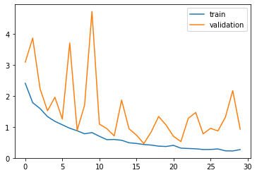

```python
# I will train for 30 epochs with a batch size of 50 using the training and validation set
history = model.fit(X_train,
                    y_train,
                    batch_size=50,
                    epochs=30,
                    validation_data=(X_val, y_val),
                    shuffle=True,
                    verbose=1)

# plot training history
plt.plot(history.history['loss'], label='train')
plt.plot(history.history['val_loss'], label='validation')
plt.legend()
plt.show()
```

```python
results = model.evaluate(X_test, y_test)
print('Test loss:', results[0])
print('Test accuracy:', results[1])
```

```
Test loss: 0.98680579662323
Test accuracy: 0.7359550595283508
```

Insights: Overall, I obtained a test accuracy of 73.5% which is decent. From the plot, note that my training loss steadily decreases while the validation loss bounces around significantly.

```python
predictions = model.predict(X_test)
preds = []
for i in range(len(predictions)):
     preds.append(np.argmax(predictions[i]))
```

```python
class_map = {
0:"Black-grass",
1:"Charlock",
2:"Cleavers",
3:"Common Chickweed",
4:"Common wheat",
5:"Fat Hen",
6:"Loose Silky-bent",
7:"Maize",
8:"Scentless Mayweed",
9:"Shepherds Purse",
10:"Small-flowered Cranesbill",
11:"Sugar beet",
}
y_pred = list(map(class_map.get, preds))
```

```python
y_pred
```

```
['Common Chickweed',
 'Scentless Mayweed',
 'Loose Silky-bent',
 'Small-flowered Cranesbill',
 'Fat Hen',
 'Fat Hen',
 'Scentless Mayweed',
 'Small-flowered Cranesbill',
 'Charlock',
 'Loose Silky-bent',
 'Loose Silky-bent',
 'Common Chickweed',
 'Small-flowered Cranesbill',
 'Scentless Mayweed',
 'Shepherds Purse',
 'Maize',
 'Common wheat',
 'Loose Silky-bent',
 'Scentless Mayweed',
 'Common Chickweed',
 'Common Chickweed',
 'Sugar beet',
 'Loose Silky-bent',
 'Fat Hen',
 'Sugar beet',
 'Loose Silky-bent',
 'Charlock',
 'Common Chickweed',
 'Common Chickweed',
 'Small-flowered Cranesbill',
 'Black-grass',
 'Common Chickweed',
 'Common Chickweed',
 'Sugar beet',
 'Common wheat',
 'Common Chickweed',
 'Loose Silky-bent',
 'Common Chickweed',
 'Common Chickweed',
 'Small-flowered Cranesbill',
```

[output cut: 657 more lines]

```
 'Sugar beet',
 'Loose Silky-bent',
 'Fat Hen',
 'Common Chickweed',
 'Fat Hen',
 'Shepherds Purse',
 'Loose Silky-bent',
 'Scentless Mayweed',
 'Loose Silky-bent',
 'Loose Silky-bent',
 'Sugar beet',
 'Scentless Mayweed',
 'Charlock',
 'Loose Silky-bent',
 'Scentless Mayweed']
```

```python
y_true
```

```
['Maize',
 'Loose Silky-bent',
 'Loose Silky-bent',
 'Small-flowered Cranesbill',
 'Fat Hen',
 'Fat Hen',
 'Scentless Mayweed',
 'Small-flowered Cranesbill',
 'Charlock',
 'Black-grass',
 'Loose Silky-bent',
 'Common Chickweed',
 'Small-flowered Cranesbill',
 'Scentless Mayweed',
 'Charlock',
 'Maize',
 'Common wheat',
 'Loose Silky-bent',
 'Scentless Mayweed',
 'Common Chickweed',
 'Small-flowered Cranesbill',
 'Sugar beet',
 'Small-flowered Cranesbill',
 'Fat Hen',
 'Sugar beet',
 'Loose Silky-bent',
 'Charlock',
 'Small-flowered Cranesbill',
 'Common Chickweed',
 'Small-flowered Cranesbill',
 'Fat Hen',
 'Common Chickweed',
 'Common Chickweed',
 'Maize',
 'Common wheat',
 'Common Chickweed',
 'Loose Silky-bent',
 'Common Chickweed',
 'Small-flowered Cranesbill',
 'Small-flowered Cranesbill',
```

[output cut: 657 more lines]

```
 'Sugar beet',
 'Loose Silky-bent',
 'Fat Hen',
 'Common Chickweed',
 'Fat Hen',
 'Charlock',
 'Loose Silky-bent',
 'Common Chickweed',
 'Fat Hen',
 'Loose Silky-bent',
 'Sugar beet',
 'Scentless Mayweed',
 'Charlock',
 'Black-grass',
 'Scentless Mayweed']
```

```python
from sklearn.metrics import confusion_matrix
y_true = list(y_test1[0])
labels = ["Black-grass","Charlock", "Cleavers","Common Chickweed","Common wheat", "Fat Hen",
"Loose Silky-bent","Maize","Scentless Mayweed","Shepherds Purse","Small-flowered Cranesbill","Sugar beet" ]
confmat = confusion_matrix(y_true, y_pred, labels = labels)
```

```
<sklearn.metrics._plot.confusion_matrix.ConfusionMatrixDisplay at 0x7fa25fdfd050>
```

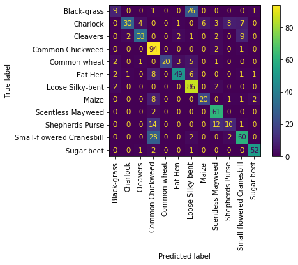

```python
from sklearn.metrics import ConfusionMatrixDisplay
disp = ConfusionMatrixDisplay(confusion_matrix=confmat,
                              display_labels=labels)
disp.plot(xticks_rotation = 'vertical')
```

Insights: We can see that the model did a decent job since we have large values on the diagonal. The model seems to mistake the Small-flowered Cranesbill and Shepherds Purse often for the Common Chickweed. It also seems to mistake Black-Grass for the Loose Silky-bent often. The Common Chickweed and loose-sily bent was predicted correctly the most overall. In the beginning of the analysis, we saw that these two classes have the most observations. Thus, it makes sense that our model predicts these well since it trained on a larger proportion of this class

# Visualizing Predictions

[output not shown]

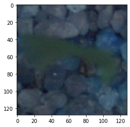

```python
plt.imshow(X_test9[2])
y_pred[2]
```

[output not shown]

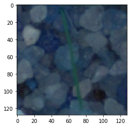

```python
plt.imshow(X_test9[3])
y_pred[3]
```

[output not shown]

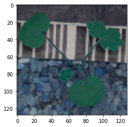

```python
plt.imshow(X_test9[33])
y_pred[33]
```

[output not shown]

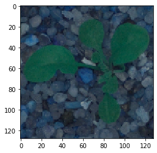

```python
plt.imshow(X_test9[36])
y_pred[36]
```

```
'Cleavers'
```

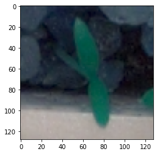

```python
plt.imshow(X_test9[59])
y_pred[59]
```

```python
from sklearn.metrics import classification_report
print(classification_report(y_true, y_pred, target_names=labels))
```

```
                           precision    recall  f1-score   support

              Black-grass       0.60      0.24      0.35        37
                 Charlock       0.91      0.51      0.65        59
                 Cleavers       0.85      0.67      0.75        49
         Common Chickweed       0.60      0.97      0.74        97
             Common wheat       1.00      0.62      0.77        32
                  Fat Hen       0.89      0.72      0.80        68
         Loose Silky-bent       0.68      0.96      0.79        90
                    Maize       0.77      0.62      0.69        32
        Scentless Mayweed       0.73      0.97      0.84        63
          Shepherds Purse       0.48      0.27      0.34        37
Small-flowered Cranesbill       0.75      0.65      0.70        92
               Sugar beet       0.93      0.93      0.93        56

                 accuracy                           0.74       712
                macro avg       0.77      0.68      0.70       712
             weighted avg       0.76      0.74      0.72       712
```

Insights: As we can see, our model does a decent job of correctly classifying the grass types. Judging by the f1-score, Black-Grass and Shepherds Purse are the types of grass that our model found difficult to classify the grass types. The Common Chickweed and Scentless Mayweed had the highest recall scores, meaning that our model predicts these classes accurately most of the time. In the future, training for more epochs would possibly yield higher performance based on the trend in the plot made previously. More data for other classes are needed to have an even distribution of observations per class. In the beginning of the analysis we saw that classes including Cleavers, Black-Grass, Common Wheat, and Maize have far smaller number of observations than other classes. Gathering data will significantly improve the model performance as it will be able to train more evenly across all classes.